# Data Analysis Project - STAT 420 - Group Project

Luma Vasiljevic(lumav2), Sushanta Panda(panda5)

# Introduction

### Description of the dataset:

##### **Dataset Link:**

http://www.statsci.org/data/general/fev.html

##### **Variables in the Dataset:**

| VariableName | Category | Description |
| --- | --- | --- |
| ID | Numeric | Uniquely Identified Row |
| Age | Numeric | Age of the child |
| Height | Numeric | Height of the child in inches |
| Sex | Categorical | Sex of the child |
| Smoker | Categorical | Whether the child is a non-smoker or current smoker |
| FEV | Numeric | FEV of the child in litres |

##### **Background information of the dataset:**

Note: No citation required for this source (http://www.statsci.org/data/general/fev.html)

### Why is it interesting:

This dataset has chosen by us because of personal interests, whether we can predict the child’s FEV with the help of the available predictor, rather going for a Pulmonary Function Test, which will identify any pulmonary disease of a child. And secondly, to do statistical analysis on what are the predictors responsible to increase / decrease the pulmonary function of the child and try to find answer on these lines.

### Why are we creating a model of this Data:

In order to **predict the child’s Forced Exporatory Volume (FEV)** based on the Child’s Age, Height, Sex and whether the child is a smoker or not. This will help for kick-start the treatment of the child based on the FEV reading, rather going throgh the Pulmonary Function test.

### Goal of the Model:

The goal of the model is to find the best model after going through the several methods, which predict the child’s FEV with minimal error. The best model would have the lowest Root Mean Square Error (RMSE) against Leave One Out cross validation (LOOCV).

# Methods

We will be doing several data analysis and methods in this section, where each section will be describing what’s the part of the tasks.

### Load FEV data, Observations:

```r
childfev = read.csv("http://www.statsci.org/data/general/fev.txt",
                    sep = "\t",
                    quote = "\"",
                    comment.char = "",
                    stringsAsFactors = FALSE)
childfev$Sex = as.factor(childfev$Sex)
childfev$Smoker = as.factor(childfev$Smoker)
str(childfev)
```

```
## 'data.frame':    654 obs. of  6 variables:
##  $ ID    : int  301 451 501 642 901 1701 1752 1753 1901 1951 ...
##  $ Age   : int  9 8 7 9 9 8 6 6 8 9 ...
##  $ FEV   : num  1.71 1.72 1.72 1.56 1.9 ...
##  $ Height: num  57 67.5 54.5 53 57 61 58 56 58.5 60 ...
##  $ Sex   : Factor w/ 2 levels "Female","Male": 1 1 1 2 2 1 1 1 1 1 ...
##  $ Smoker: Factor w/ 2 levels "Current","Non": 2 2 2 2 2 2 2 2 2 2 ...
```

```r
dim(childfev)
```

```
## [1] 654   6
```

```r
head(childfev$FEV,10)
```

```
##  [1] 1.708 1.724 1.720 1.558 1.895 2.336 1.919 1.415 1.987 1.942
```

From the dataset, it observered data, Age, Heigh is a numerical variable, where as Sex / Smoker field is a categorical variable. The FEV is the numerical **response** variable.

##### **Load FEV data**

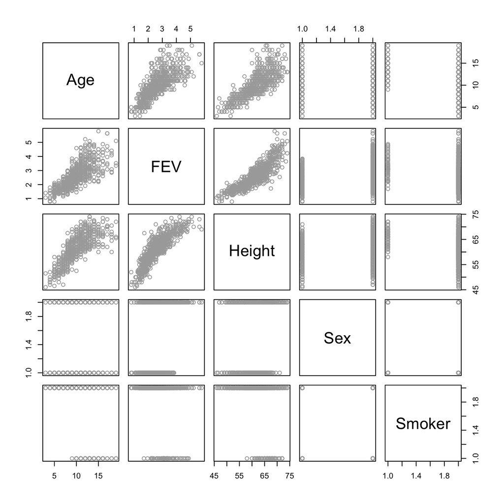

```r
pairs(childfev[c('Age','FEV','Height','Sex','Smoker')], col = "darkgrey")
```

**Let’s check the Correlation Matrix to explore what’s the co-relation among the variables**

```r
cor(childfev[c('Age','Height','FEV')])
```

```
##           Age Height    FEV
## Age    1.0000 0.7919 0.7565
## Height 0.7919 1.0000 0.8681
## FEV    0.7565 0.8681 1.0000
```

It seems that what the pair plot shows seems correct, from the corelation matrix it also suggests that `Age` and `Height` are higly corelation with `FEV` response, as well as among it self, We need to explore the variance inflation factor (VIF) while creating our model in further.

##### **Categorical Data of Sex and Smoker**

```r
table(childfev$Sex)
```

```
##
## Female   Male
##    318    336
```

```r
table(childfev$Smoker)
```

```
##
## Current     Non
##      65     589
```

### Model 1 - Multiple Linear Regression (MLR) FEV data:

Let’s start with the Multiple Linear Regression (MLR) against all the predictor (Except the ID), to predict the FEV as the response

```r
mlr_model = lm(FEV ~ Age + Height + Sex + Smoker, data = childfev)
summary(mlr_model)
```

```
##
## Call:
## lm(formula = FEV ~ Age + Height + Sex + Smoker, data = childfev)
##
## Residuals:
##     Min      1Q  Median      3Q     Max
## -1.3766 -0.2503  0.0089  0.2559  1.9205
##
## Coefficients:
##             Estimate Std. Error t value Pr(>|t|)
## (Intercept) -4.54422    0.23205  -19.58  < 2e-16 ***
## Age          0.06551    0.00949    6.90  1.2e-11 ***
## Height       0.10420    0.00476   21.90  < 2e-16 ***
## SexMale      0.15710    0.03321    4.73  2.7e-06 ***
## SmokerNon    0.08725    0.05925    1.47     0.14
## ---
## Signif. codes:  0 '***' 0.001 '**' 0.01 '*' 0.05 '.' 0.1 ' ' 1
##
## Residual standard error: 0.412 on 649 degrees of freedom
## Multiple R-squared:  0.775,  Adjusted R-squared:  0.774
## F-statistic:  560 on 4 and 649 DF,  p-value: <2e-16
```

##### **Assumption of the Model**

Let’s verify the Assumption of the Model - Constant Varience - Normality

**Let’s plot Plotted Versus Residul Plot to see the distribution**

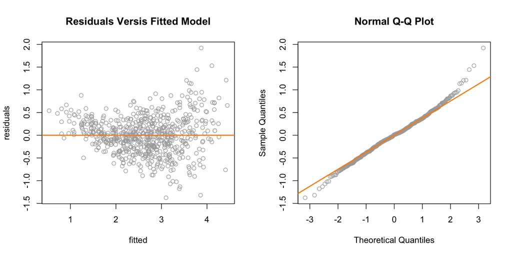

```r
par(mfrow = c(1,2))
plot(resid(mlr_model)~fitted(mlr_model), ylab = "residuals", xlab = "fitted", cex = 1, pch = 1, col = "darkgrey", main = "Residuals Versis Fitted Model")
abline(h = 0, lwd = 2, col = "darkorange")

qqnorm(resid(mlr_model), cex = 1, pch = 1, col = "darkgrey")
qqline(resid(mlr_model), lwd = 2, col = "darkorange")
```

From the above residuals versus fitted plot, it seems the **constant variance assumption is suspect**, as the residuals are not equally distributed.

This is the same case for the Q-Q plot, where both the tail seems to the a little fat tails, which tells us that **normality assuption seems suspect** for the model.

Let’s do the BP Test and Shapiro Test to gather some more evidence

```r
library(lmtest)
bptest(mlr_model)
```

```
##
##  studentized Breusch-Pagan test
##
## data:  mlr_model
## BP = 65, df = 4, p-value = 3e-13
```

The BP Test is very low which confirms that **constant variance is suspect**

```r
shapiro.test(resid(mlr_model))
```

```
##
##  Shapiro-Wilk normality test
##
## data:  resid(mlr_model)
## W = 0.99, p-value = 0.0002
```

The shapiro test also seems lkow, which confirms that the **normality assumption also seems suspect**

##### **RSS, RMSE and RMSE LOOCV**

Let’e calculate the RSS, RMSE and RMSE LOOCV of the model **RSS**

```r
sum((resid(mlr_model))^2)
```

```
## [1] 110.3
```

**RMSE**

```r
sqrt(mean(sum((resid(mlr_model))^2)))
```

```
## [1] 10.5
```

**RMSE LOOCV**

```r
sqrt(mean((resid(mlr_model)/(1-hatvalues(mlr_model)))^2))
```

```
## [1] 0.4145
```

| Metric | Value |
| --- | --- |
| RSS | 110.2796 |
| RMSE | 10.5014 |
| RMSE LOOCV | 0.4145 |

### Model 2 - Transformation of response variable FEV (Logarithimic):

Let’s explore whether transformation of the response variable `FEV` has any siginificance to improve the score (low RMSE LOOCV)

Let’s first plot the histogram of the `FEV` response variable with and without the logarathimic value

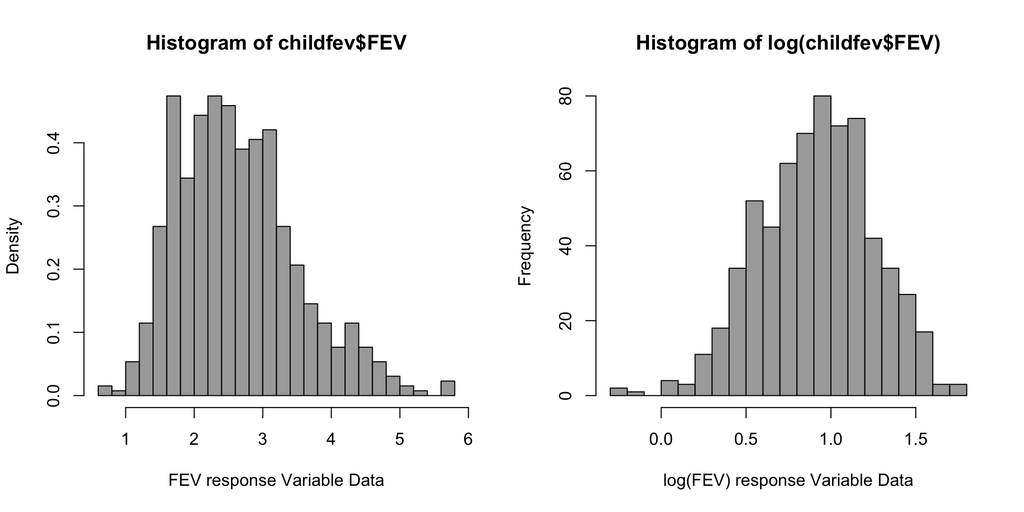

```r
par(mfrow=c(1,2))
hist(childfev$FEV,
     xlab = 'FEV response Variable Data',
     probability = TRUE,
     breaks = 20,
     col = "darkgrey",
     name = "Original FEV response")
hist(log(childfev$FEV),
     xlab = 'log(FEV) response Variable Data',
     breaks = 20,
     col = "darkgrey",
     name = "Logarithimic FEV response")
```

### Model 3 - Polynomial Transformation of Numeric Predictor

Let’s explore the polynomial transformation of the predictor to see whether we can able to find the best model which lower the RMSE LOOCV

We will carry out the following methods to identify the best model - Lowest RMSE LOOCV - Highest R2 and Adjusted R2 - Lowest Average Percentage Error - Anova F Test P value

```r
poly2_model = lm(FEV ~ Sex + Smoker + Age + Height + I(Age^2) + I(Height^2) , data = childfev)
poly3_model = lm(FEV ~ Sex + Smoker + Age + Height + I(Age^2) + I(Height^2) + I(Age^3) + I(Height^3) , data = childfev)
poly4_model = lm(FEV ~ Sex + Smoker + Age + Height + I(Age^2) + I(Height^2) + I(Age^3) + I(Height^3) + I(Age^4) + I(Height^4), data = childfev)
poly5_model = lm(FEV ~ Sex + Smoker + Age + Height + I(Age^2) + I(Height^2) + I(Age^3) + I(Height^3) + I(Age^4) + I(Height^4) + I(Age^5) + I(Height^5), data = childfev)
poly6_model = lm(FEV ~ Sex + Smoker + Age + Height + I(Age^2) + I(Height^2) + I(Age^3) + I(Height^3) + I(Age^4) + I(Height^4) + I(Age^5) + I(Height^5) + I(Age^6) + I(Height^6), data = childfev)
```

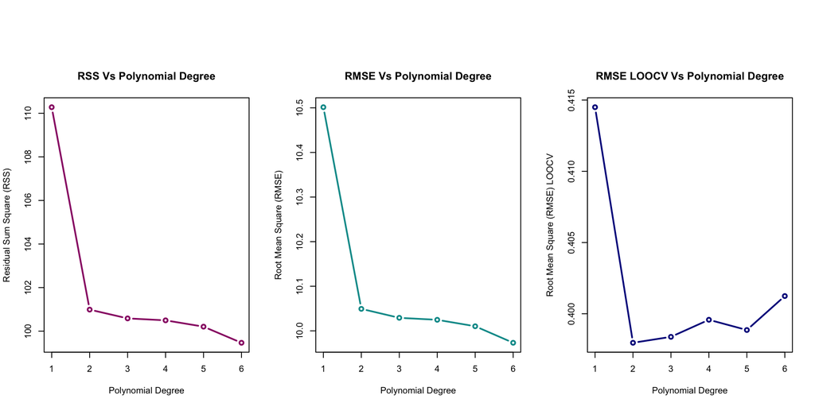

It seems that as the Polynomial degree increases, the `RSS` and `RMSE` decreases, which should be as the model becomes more and more complex, the error will decreased. However the RMSE LOOCV seems **increases** after the Polynomial degree 2. Hence it’s not been seen good, if we increase the model beyond degree 2, as the Root Mean Square Error (RMSE) Leave One Out Cross Validation Error increases.

Let’s see what happens to the R2 and Adjusted R2 when the polynomail degree increases. Also let’s see what will be the Average Percentage Error, when the Polynomail degree increases.

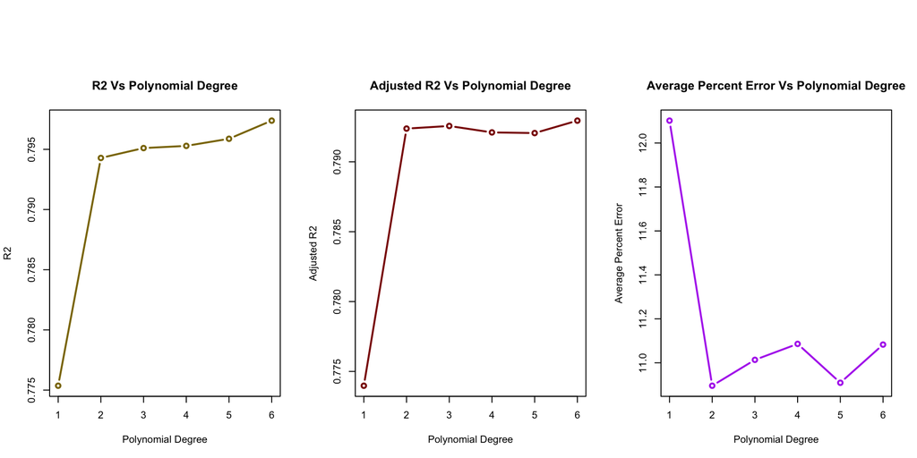

It seems the R2 keeps increasing as the Polynomial degree increases. However adjusted R2 seems mostly fixed on/beyond Polynomial degree 2. Which kind of gives enough evidence to go for the model having Polynomail degree 2.

which depicts that the percentage of error doesn’t decrease after Polynomial degree 2, and increased. This also have inclination towards the Polynomial Regression model with Degree 2.

Let’s do an Inova F Test to compare these models, to see whether the Polynomial degree has significance or not.

##### **Anova F Test**

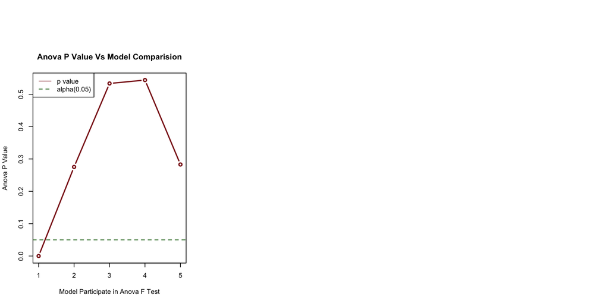

Each point shows the `p value` comes from the Anova F Test between `Polynomial Regresssion of degree 1` Vs `Polynomial Regresssion of degree 2` and rest all points are between `Polynomial Regresssion of degree 2` and `Polynomial Regresssion of degree 3/4/5/6`. It clearly observed that for alpha value **`0.05`** we **failed to reject all hypothesis** of estimated parameters to be zero for Polynomial of degree more than 2.

Let’s see the comparision of the data in actual between all the models, to concrete the Model with Polynomial regression of degree 2 is the best model

| ID | Interaction_Model | rss | rmse | rmse_loocv | r2 | adj_r2 |
| --- | --- | --- | --- | --- | --- | --- |
| 1 | MLR | 110.28 | 10.501 | 0.4145 | 0.7754 | 0.7740 |
| 2 | Polynomial Degree 2 | 100.99 | 10.049 | 0.3980 | 0.7943 | 0.7924 |
| 3 | Polynomial Degree 3 | 100.59 | 10.029 | 0.3984 | 0.7951 | 0.7926 |
| 4 | Polynomial Degree 4 | 100.50 | 10.025 | 0.3996 | 0.7953 | 0.7921 |
| 5 | Polynomial Degree 5 | 100.21 | 10.010 | 0.3989 | 0.7959 | 0.7921 |
| 6 | Polynomial Degree 6 | 99.47 | 9.973 | 0.4012 | 0.7974 | 0.7929 |

### Model 4 - Interaction between Predictors:

Following are the exploration needs to be done as part of the Interaction between the predictors - Interaction between Numerical Predictor (Age, Height) and Categorical Predictor (Sex, Smoker) - One at a Time - Interaction between Numerical Predictors (Age, Height) it self - Interaction between all of the them 2 way and 3 way. - Carry out Inova F Test and RMSE LOOCV and Average Percentage Error to find out what’s the best model

##### **Interaction Model:**

```r
model_age_sex = lm(FEV ~ (Age + Sex) ^ 2 , data = childfev)
model_age_smoker = lm(FEV ~ (Age + Smoker) ^ 2 , data = childfev)
model_age_sex_smoker = lm(FEV ~ Age + Sex + Smoker + Age:Sex + Age:Smoker , data = childfev)
model_height_sex = lm(FEV ~ (Height + Sex) ^ 2 , data = childfev)
model_height_smoker = lm(FEV ~ (Height + Smoker) ^ 2 , data = childfev)
model_height_sex_smoker = lm(FEV ~ Height + Sex + Smoker + Height:Sex + Height:Smoker , data = childfev)
model_all_int_except_age_height = lm(FEV ~ Age + Height + Sex + Smoker + Age:Sex + Age:Smoker + Height:Sex + Height:Smoker, data = childfev)
model_all_int_with_age_height = lm(FEV ~ Age + Height + Sex + Smoker + Age:Sex + Age:Smoker + Height:Sex + Height:Smoker + Age:Height, data = childfev)
model_all_2way = lm(FEV ~ (Age + Height + Sex + Smoker) ^ 2, data = childfev)
model_all_3way = lm(FEV ~ (Age + Height + Sex + Smoker) ^ 3, data = childfev)
```

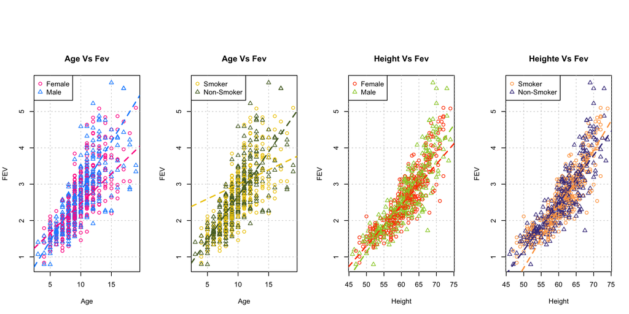

It seems that the interaction between the `Age` with categorical variable (Sex and Smoker) has changed the estimates drasticallly, than the interaction between `Height` with the Categorical variable (Sex and Smoker).

Let’s conduct the Anova F Test to verify, which interaction is significance and which is not

##### **Anova F Test**

| ID | null_Model | full_Model | p_value | descision |
| --- | --- | --- | --- | --- |
| 1 | Age+Sex+Age:Sex | Age+Sex+Smoker+Age:Sex+Age:Smoker | 0.0000 | Age+Sex+Smoker+Age:Sex+Age:Smoker |
| 2 | Age+Smoker+Age:Smoker | Age+Sex+Smoker+Age:Sex+Age:Smoker | 0.0000 | Age+Sex+Smoker+Age:Sex+Age:Smoker |
| 3 | Height+Sex+Height:Sex | Height+Sex+Smoker+Height:Sex+Height:Smoker | 0.4218 | Height+Sex+Height:Sex |
| 4 | Height+Smoker+Height:Smoker | Height+Sex+Smoker+Height:Sex+Height:Smoker | 0.0000 | Height+Sex+Smoker+Height:Sex+Height:Smoker |
| 5 | Age+Sex+Smoker+Age:Sex+Age:Smoker | Age+Height+Age:Sex+Age:Smoker+Height:Sex+Height:Smoker | 0.0000 | Age+Height+Age:Sex+Age:Smoker+Height:Sex+Height:Smoker |
| 6 | Height+Sex+Height:Sex | Age+Height+Age:Sex+Age:Smoker+Height:Sex+Height:Smoker | 0.0000 | Age+Height+Age:Sex+Age:Smoker+Height:Sex+Height:Smoker |
| 7 | Height+Sex+Smoker+Height:Sex+Height:Smoker | Age+Height+Age:Sex+Age:Smoker+Height:Sex+Height:Smoker | 0.0000 | Age+Height+Age:Sex+Age:Smoker+Height:Sex+Height:Smoker |
| 8 | Age+Height+Age:Sex+Age:Smoker+Height:Sex+Height:Smoker | Age+Height+Age:Sex+Age:Smoker+Height:Sex+Height:Smoker+Age:Height | 0.0000 | Age+Height+Age:Sex+Age:Smoker+Height:Sex+Height:Smoker+Age:Height |
| 9 | Age+Height+Age:Sex+Age:Smoker+Height:Sex+Height:Smoker+Age:Height | 2 way | 0.8041 | Age+Height+Age:Sex+Age:Smoker+Height:Sex+Height:Smoker+Age:Height |
| 10 | Age+Height+Age:Sex+Age:Smoker+Height:Sex+Height:Smoker+Age:Height | 3 way | 0.0000 | 3way |

It seems the 3 way interaction seems significance among all the interaction between the numeric and categorical variable.

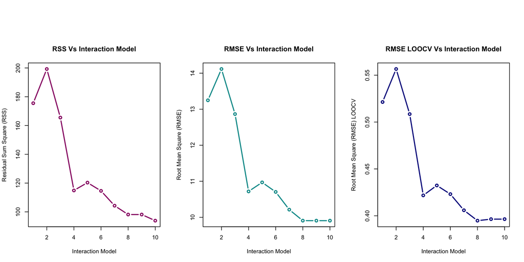

Let’s see what happens to the R2 and Adjusted R2 when the polynomail degree increases. Also let’s see what will be the Average Percentage Error, when the Polynomail degree increases.

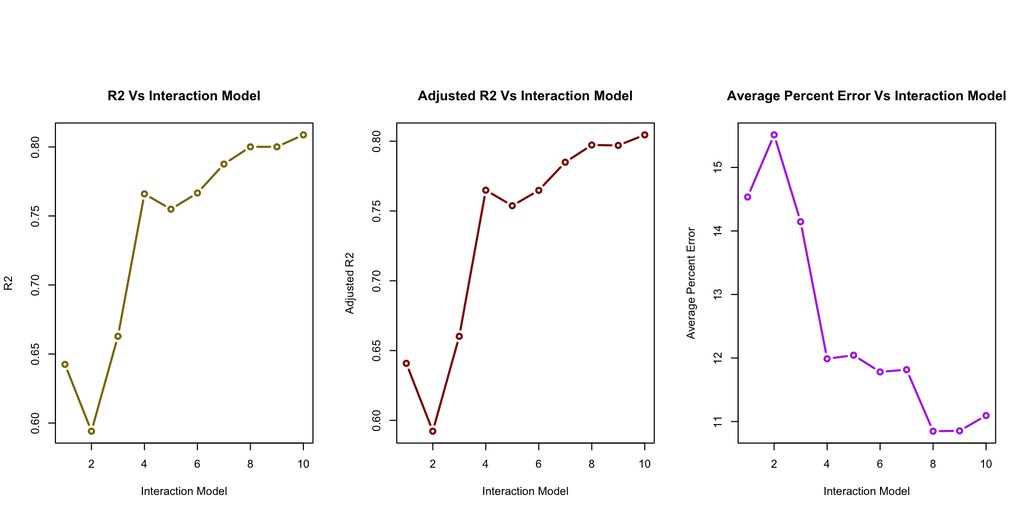

Let’s see the comparision of the data in actual between all the models, to see what’s the best finalize model

[output not shown]

### Model 5 - Creation of Big Model (Polynomial + Interaction), Stepwise via AIC / BIC:

Let’s create a big model, with Polynomial of degree 3 and 3 way interaction between categorical-to-categorical, categorical-to-numeric, numeric-to-numeric and see it’s score.

##### **Big Model: + 3 other model**

```r
big_model = lm(FEV ~ (Age + Height + Sex + Smoker) ^ 3 + I(Age^2) + I(Height^2) + I(Age^3) + I(Height^3), data = childfev) # Big Model - Polynomial degree 3 + 3 Way Interaction
poly2_int_model8 = lm(FEV ~ Age + Height + Sex + Smoker + Age:Sex + Age:Smoker + Height:Sex + Height:Smoker + Age:Height , data = childfev) # Polynomial degree 2 + All Interaction Except Sex:Smoker
poly2_int_model9 = lm(FEV ~ (Age + Height + Sex + Smoker) ^ 2, data = childfev) # Polynomial degree 2 + 2 Way Interaction
poly2_int_model10 = lm(FEV ~ (Age + Height + Sex + Smoker) ^ 3, data = childfev) # Polynomial degree 2 + 3 Way Interaction
```

Let’s compare with the good model from the Interaction model and Polynomial Regression Model, to see which one is siginificance

Let’s do the AIC and BIC to see what’ the outcome, after do the ANOVA F Test.

##### **AIC, BIC of the Big Model:**

**ANOVA F Test of the AIC/BIC**

| ID | null_Model | full_Model | p_value | descision |
| --- | --- | --- | --- | --- |
| 1 | Polynomial Degree 2 | Big Model | 0.0000 | Big Model |
| 2 | All Interaction Except Sex:Smoker | Big Model | 0.0001 | Big Model |
| 3 | 2 way | Big Model | 0.0000 | Big Model |
| 4 | 3 way | Big Model | 0.2198 | 3 way |
| 5 | Polynomial Degree 2 + All Interaction Except Sex:Smoker | Big Model | 0.0001 | Big Model |
| 6 | Polynomial Degree 2 + 2 way | Big Model | 0.0000 | Big Model |
| 7 | Polynomial Degree 2 + 3 way | Big Model | 0.2198 | Polynomial Degree 2 + 3 way |
| 8 | Big Model - AIC | Big Model | 0.7976 | Big Model - AIC |
| 9 | Big Model - BIC | Big Model | 0.3877 | Big Model - BIC |
| 10 | AIC - Polynomial Degree 2 + All Interaction Except Sex:Smoker | Big Model | 0.0003 | Big Model |
| 11 | BIC - Polynomial Degree 2 + All Interaction Except Sex:Smoker | Big Model | 0.0000 | Big Model |
| 12 | AIC - Polynomial Degree 2 + 2 way | Big Model | 0.0003 | Big Model |
| 13 | BIC- Polynomial Degree 2 + 2 way | Big Model | 0.0000 | Big Model |
| 14 | AIC - Polynomial Degree 2 + 3 way | Big Model | 0.3877 | AIC - Polynomial Degree 2 + 3 way |
| 15 | BIC - Polynomial Degree 2 + 3 way | Big Model | 0.3877 | BIC - Polynomial Degree 2 + 3 way |

From the above table (Anova F Test), It sees the Big Table or the 3 Way Interaction or 3 Way Interaction + Polynomial degree 2 is of higher significance.

##### **RSS, RMSE and RMSE LOOCV**

Let’e calculate the RSS, RMSE and RMSE LOOCV of the model **RSS**

```r
sum((resid(big_model))^2)
```

```
## [1] 93.05
```

**RMSE**

```r
sqrt(mean(sum((resid(big_model))^2)))
```

```
## [1] 9.646
```

**RMSE LOOCV**

```r
sqrt(mean((resid(big_model)/(1-hatvalues(big_model)))^2))
```

```
## [1] 0.3925
```

| Metric | Value |
| --- | --- |
| RSS | 93.0501 |
| RMSE | 9.6462 |
| RMSE LOOCV | 0.3925 |

The RMSE LOOCV seems better than that of `Multiple Linear Regression`. We will compare at the last while making the decission around models

##### **Reduced Big Model via AIC :**

```r
big_model = lm(FEV ~ (Age + Height + Sex + Smoker) ^ 3 + poly(Age,3) + poly(Height,3), data = childfev)
big_model_aic = step(big_model, direction = "backward", trace = 0)
summary(big_model_aic)
```

```
##
## Call:
## lm(formula = FEV ~ Age + Height + Sex + Smoker + poly(Height,
##     3) + Age:Height + Age:Sex + Age:Smoker + Height:Sex + Height:Smoker +
##     Sex:Smoker + Age:Height:Sex + Height:Sex:Smoker, data = childfev)
##
## Residuals:
##     Min      1Q  Median      3Q     Max
## -1.3035 -0.2190 -0.0021  0.2167  1.6067
##
## Coefficients: (1 not defined because of singularities)
##                            Estimate Std. Error t value Pr(>|t|)
## (Intercept)               0.2954728  2.5352999    0.12  0.90726
## Age                      -0.0097005  0.1592017   -0.06  0.95143
## Height                    0.0423046  0.0388440    1.09  0.27653
## SexMale                  -3.4622592  3.0293083   -1.14  0.25350
## SmokerNon                -3.5027204  1.9922327   -1.76  0.07919 .
## poly(Height, 3)1                 NA         NA      NA       NA
## poly(Height, 3)2          0.0748272  0.8601746    0.09  0.93071
## poly(Height, 3)3         -0.9398997  0.4368687   -2.15  0.03182 *
## Age:Height                0.0000545  0.0024431    0.02  0.98221
## Age:SexMale              -0.5785139  0.1482446   -3.90  0.00011 ***
## Age:SmokerNon             0.0734381  0.0245113    3.00  0.00284 **
## Height:SexMale            0.0480355  0.0467074    1.03  0.30414
## Height:SmokerNon          0.0408410  0.0304463    1.34  0.18026
## SexMale:SmokerNon         7.1999317  2.6065228    2.76  0.00591 **
## Age:Height:SexMale        0.0093680  0.0023237    4.03 0.000062 ***
## Height:SexMale:SmokerNon -0.1077336  0.0396057   -2.72  0.00670 **
## ---
## Signif. codes:  0 '***' 0.001 '**' 0.01 '*' 0.05 '.' 0.1 ' ' 1
##
## Residual standard error: 0.382 on 639 degrees of freedom
## Multiple R-squared:  0.81,   Adjusted R-squared:  0.806
## F-statistic:  195 on 14 and 639 DF,  p-value: <2e-16
```

##### **RSS, RMSE and RMSE LOOCV**

Let’e calculate the RSS, RMSE and RMSE LOOCV of the model **RSS**

```r
sum((resid(big_model_aic))^2)
```

```
## [1] 93.29
```

**RMSE**

```r
sqrt(mean(sum((resid(big_model_aic))^2)))
```

```
## [1] 9.659
```

**RMSE LOOCV**

```r
sqrt(mean((resid(big_model_aic)/(1-hatvalues(big_model_aic)))^2))
```

```
## [1] 0.3897
```

| Metric | Value |
| --- | --- |
| RSS | 93.2936 |
| RMSE | 9.6589 |
| RMSE LOOCV | 0.3897 |

The RMSE LOOCV seems better than that of `Multiple Linear Regression`. We will compare at the last while making the decission around models